# hwk_2

Holden Jones

2025-01-28

factorially implemented experimental treatments (N:P ratio, light, nutrient level, grazer presence, grazer predator presence) - only use balanced N:P treatment, include both light levels but not look at effects of light

```r
library(tidyverse)
library(effects)
library(emmeans)
data <- read_csv('data/leibold_mesocosm_data_subset.csv')
```

# 1.

Create a linear model that tests whether richness is explained by nutrient level and/or food web treatment, and whether the effect of food web treatment differs between nutrient levels, while also accounting for the blocked structure of the experiment.

```r
rich_model <- lm(Phyto_Chao1 ~ NutrientLevel + FoodWeb +
                   NutrientLevel*FoodWeb + Block,
            data = data)
summary(rich_model)
```

```
##
## Call:
## lm(formula = Phyto_Chao1 ~ NutrientLevel + FoodWeb + NutrientLevel *
##     FoodWeb + Block, data = data)
##
## Residuals:
##     Min      1Q  Median      3Q     Max
## -8.0040 -3.2187  0.0802  2.1989  9.1714
##
## Coefficients:
##                         Estimate Std. Error t value Pr(>|t|)
## (Intercept)              11.3810     2.6078   4.364 0.000125 ***
## NutrientLevelL            2.4375     2.5559   0.954 0.347402
## FoodWebG                  6.1563     2.5559   2.409 0.021946 *
## FoodWebP                 -0.3040     2.7548  -0.110 0.912823
## Block                    -0.5524     0.7006  -0.788 0.436212
## NutrientLevelL:FoodWebG   0.5817     3.6165   0.161 0.873237
## NutrientLevelL:FoodWebP   5.1465     3.8425   1.339 0.189895
## ---
## Signif. codes:  0 '***' 0.001 '**' 0.01 '*' 0.05 '.' 0.1 ' ' 1
##
## Residual standard error: 4.733 on 32 degrees of freedom
## Multiple R-squared:  0.4038, Adjusted R-squared:  0.292
## F-statistic: 3.613 on 6 and 32 DF,  p-value: 0.007547
```

#2. Why is it important to account for the blocks? - Eventually will want to include block as a random effect, right? - Important to account for b/c different blocks could have different light availability, freshwater sources.. etc. lots of different things depending on how the study was performed

# 3.

Analyze the results of the linear model as we did in Homework 1. What is your interpretation of these results so far?

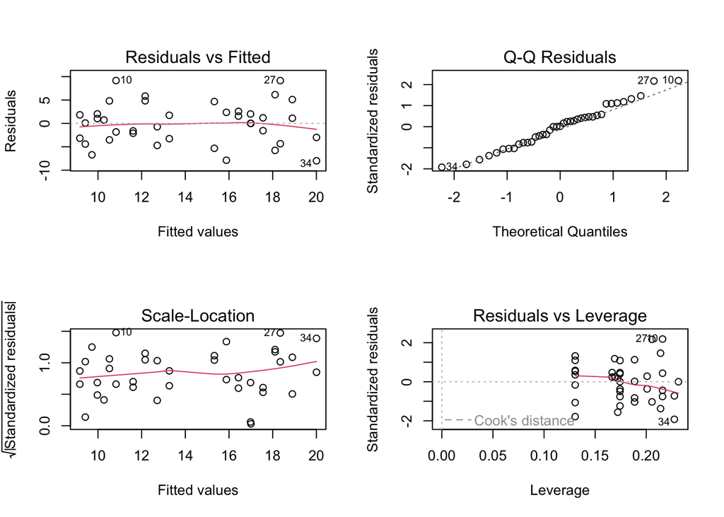

```r
par(mfrow = c(2, 2))
plot(rich_model)
```

```r
# residual plots look good - not concerned about scaling data

# anova
anova(rich_model)
```

```
## Analysis of Variance Table
##
## Response: Phyto_Chao1
##                       Df Sum Sq Mean Sq F value   Pr(>F)
## NutrientLevel          1 116.52 116.519  5.2022 0.029359 *
## FoodWeb                2 305.63 152.814  6.8226 0.003405 **
## Block                  1  16.91  16.908  0.7549 0.391401
## NutrientLevel:FoodWeb  2  46.45  23.223  1.0368 0.366185
## Residuals             32 716.74  22.398
## ---
## Signif. codes:  0 '***' 0.001 '**' 0.01 '*' 0.05 '.' 0.1 ' ' 1
```

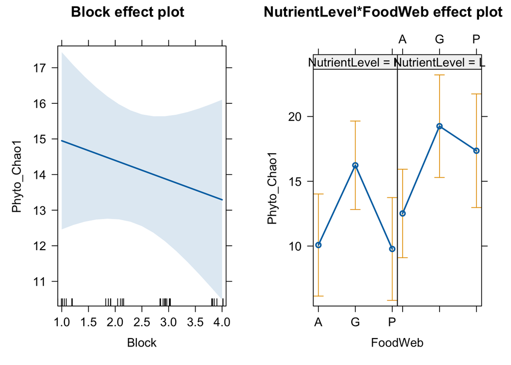

```r
# effects plot
par(mfrow = c(2, 2))
plot(allEffects(rich_model))
```

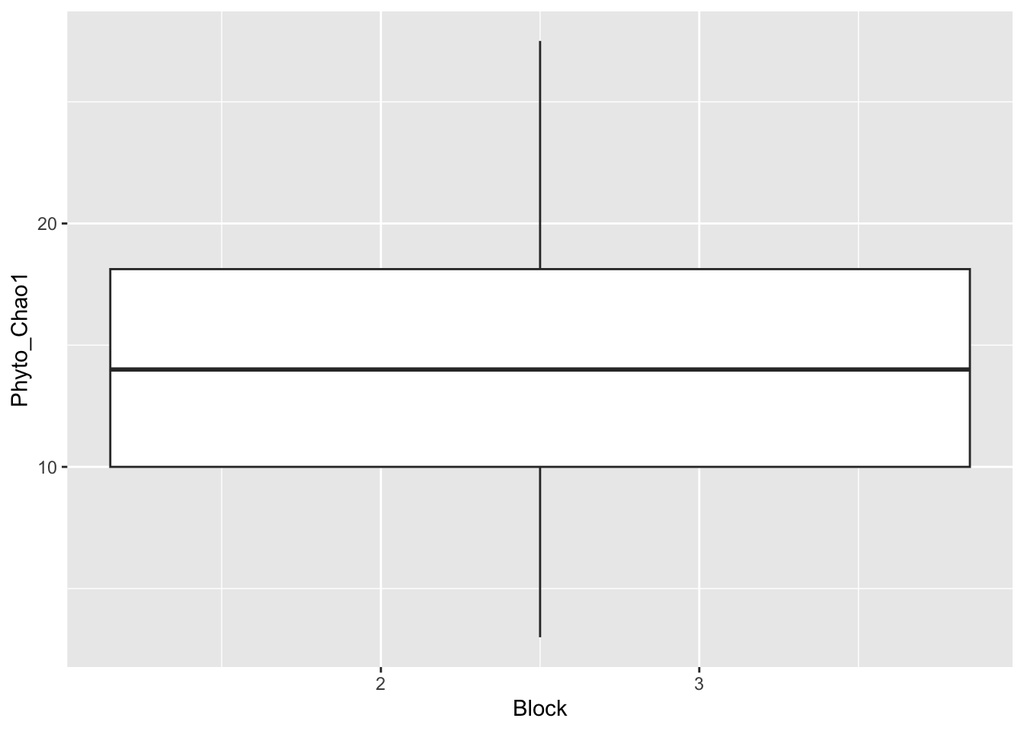

```r
ggplot(data, aes(x = Block, y = Phyto_Chao1)) +
  geom_boxplot()
```

treat block as a factor

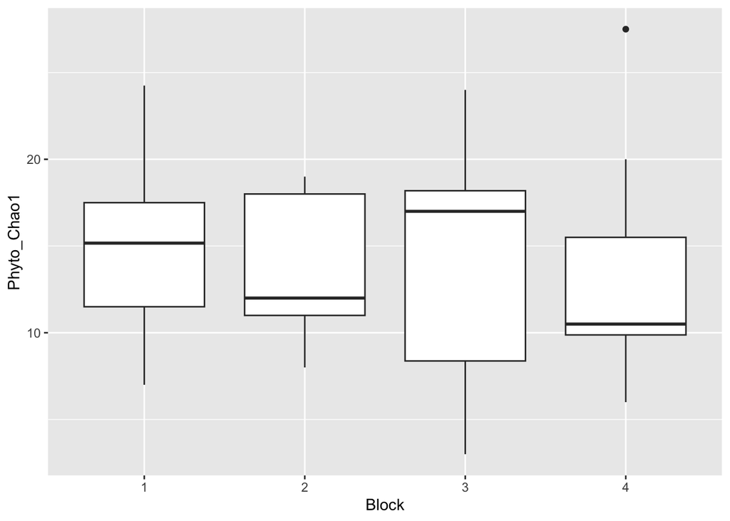

```r
# seems like need to treat Block as factor
data$Block <- as.factor(data$Block)

ggplot(data, aes(x = Block, y = Phyto_Chao1)) +
  geom_boxplot()
```

```r
rich_model <- lm(Phyto_Chao1 ~ NutrientLevel + FoodWeb +
                   NutrientLevel*FoodWeb + Block,
            data = data)
summary(rich_model)
```

```
##
## Call:
## lm(formula = Phyto_Chao1 ~ NutrientLevel + FoodWeb + NutrientLevel *
##     FoodWeb + Block, data = data)
##
## Residuals:
##     Min      1Q  Median      3Q     Max
## -7.9575 -3.1031  0.1463  2.2300  9.2563
##
## Coefficients:
##                         Estimate Std. Error t value Pr(>|t|)
## (Intercept)              10.7437     2.3171   4.637 6.48e-05 ***
## NutrientLevelL            2.3912     2.6524   0.902   0.3745
## FoodWebG                  6.1100     2.6524   2.304   0.0284 *
## FoodWebP                 -0.3990     2.9133  -0.137   0.8920
## Block2                   -0.1676     2.1969  -0.076   0.9397
## Block3                   -0.9499     2.1048  -0.451   0.6550
## Block4                   -1.6725     2.3149  -0.722   0.4756
## NutrientLevelL:FoodWebG   0.7125     3.7948   0.188   0.8523
## NutrientLevelL:FoodWebP   5.1877     3.9864   1.301   0.2030
## ---
## Signif. codes:  0 '***' 0.001 '**' 0.01 '*' 0.05 '.' 0.1 ' ' 1
##
## Residual standard error: 4.885 on 30 degrees of freedom
## Multiple R-squared:  0.4046, Adjusted R-squared:  0.2458
## F-statistic: 2.548 on 8 and 30 DF,  p-value: 0.03008
```

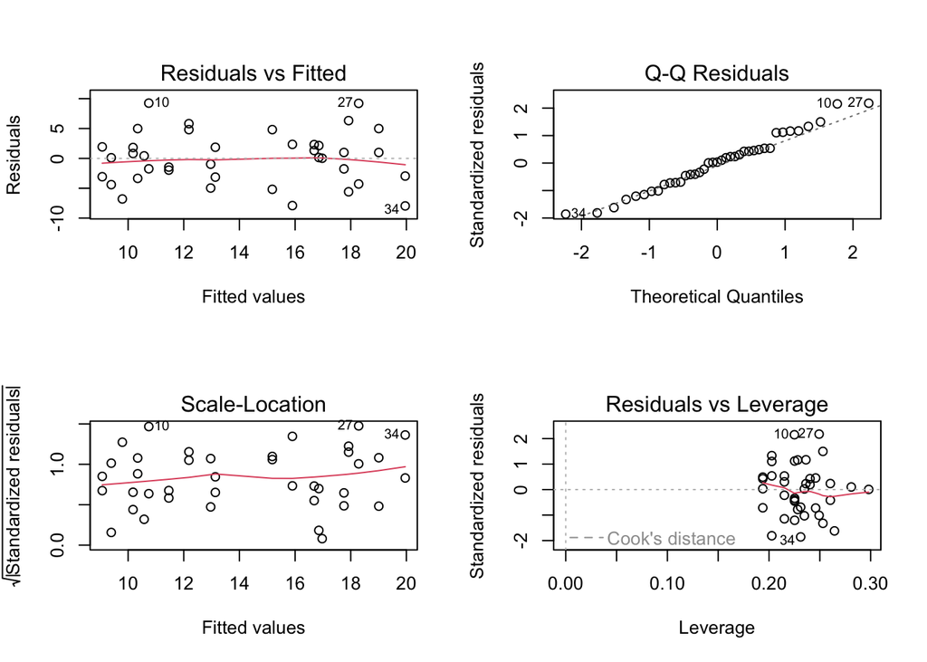

```r
par(mfrow = c(2, 2))
plot(rich_model)
```

```r
# residual plots look good - not concerned about scaling data

# anova
anova(rich_model)
```

```
## Analysis of Variance Table
##
## Response: Phyto_Chao1
##                       Df Sum Sq Mean Sq F value  Pr(>F)
## NutrientLevel          1 116.52 116.519  4.8830 0.03490 *
## FoodWeb                2 305.63 152.814  6.4041 0.00483 **
## Block                  3  18.41   6.138  0.2572 0.85558
## NutrientLevel:FoodWeb  2  45.82  22.909  0.9601 0.39431
## Residuals             30 715.86  23.862
## ---
## Signif. codes:  0 '***' 0.001 '**' 0.01 '*' 0.05 '.' 0.1 ' ' 1
```

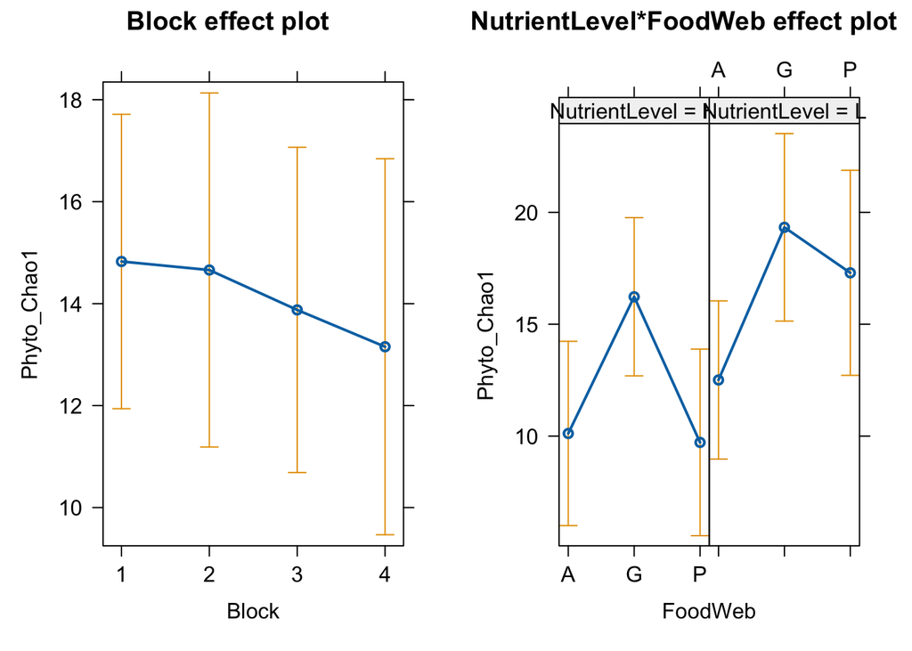

```r
# effects plots
par(mfrow = c(2, 2))
plot(allEffects(rich_model))
```

Now we will use contrasts to test some hypotheses, and we will imagine that we formulated these hypotheses a priori (as opposed to formulating them after we looked at the data). We would like to know specifically whether the grazer treatment (G) has greater richness than the algae treament (A), and whether the effect of grazers differs between high and low nutrient levels (we think the effect of grazers on coexistence may be greater at high nutrient loading).

# 4.

Use emmeans to calculate the estimated marginal means of each combination of nutrient level and food web treatment (i.e., H + A, H + G, H + P, L + A, L + G, L + P).

```r
nut_food_emmeans = emmeans(rich_model, specs = trt.vs.ctrl ~ NutrientLevel*FoodWeb)
nut_food_emmeans
```

```
## $emmeans
##  NutrientLevel FoodWeb emmean   SE df lower.CL upper.CL
##  H             A        10.05 2.01 30     5.94     14.2
##  L             A        12.44 1.73 30     8.91     16.0
##  H             G        16.16 1.73 30    12.63     19.7
##  L             G        19.26 2.05 30    15.07     23.5
##  H             P         9.65 2.06 30     5.44     13.9
##  L             P        17.23 2.26 30    12.61     21.8
##
## Results are averaged over the levels of: Block
## Confidence level used: 0.95
##
## $contrasts
##  contrast  estimate   SE df t.ratio p.value
##  L A - H A    2.391 2.65 30   0.902  0.7930
##  H G - H A    6.110 2.65 30   2.304  0.1106
##  L G - H A    9.214 2.85 30   3.237  0.0130
##  H P - H A   -0.399 2.91 30  -0.137  0.9985
##  L P - H A    7.180 3.05 30   2.353  0.1000
##
## Results are averaged over the levels of: Block
## P value adjustment: dunnettx method for 5 tests
```

# 5.

Now define contrasts to test (1) whether G is different from A in the H treatment, (2) whether G is different from A in the L treatment

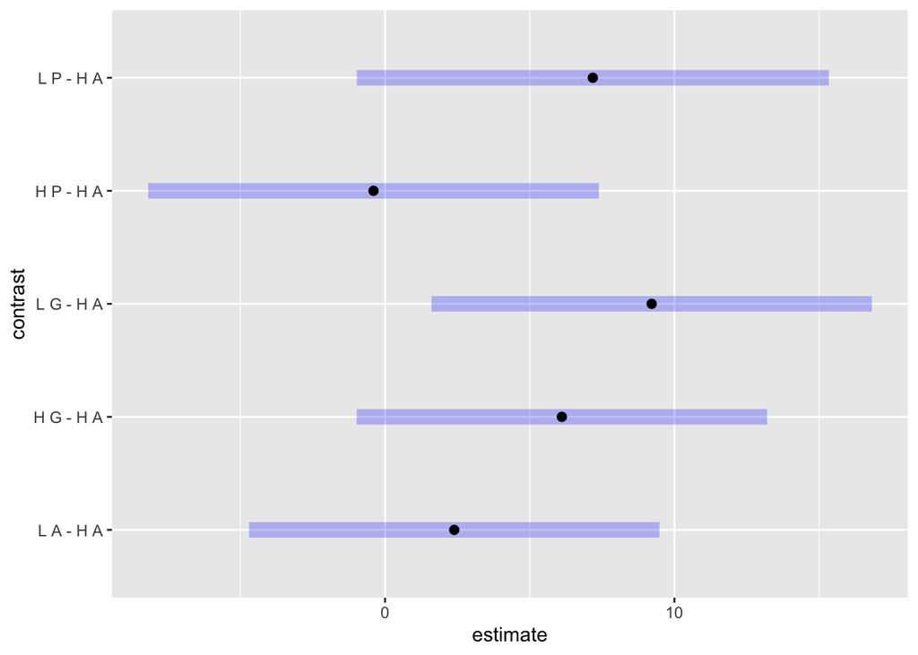

```r
# first here's all of the contrasts plotted:
plot(nut_food_emmeans$contrasts)
```

```r
# take a look at order of levels in nut_food_emmeans
nut_food_emmeans
```

```
## $emmeans
##  NutrientLevel FoodWeb emmean   SE df lower.CL upper.CL
##  H             A        10.05 2.01 30     5.94     14.2
##  L             A        12.44 1.73 30     8.91     16.0
##  H             G        16.16 1.73 30    12.63     19.7
##  L             G        19.26 2.05 30    15.07     23.5
##  H             P         9.65 2.06 30     5.44     13.9
##  L             P        17.23 2.26 30    12.61     21.8
##
## Results are averaged over the levels of: Block
## Confidence level used: 0.95
##
## $contrasts
##  contrast  estimate   SE df t.ratio p.value
##  L A - H A    2.391 2.65 30   0.902  0.7930
##  H G - H A    6.110 2.65 30   2.304  0.1106
##  L G - H A    9.214 2.85 30   3.237  0.0130
##  H P - H A   -0.399 2.91 30  -0.137  0.9985
##  L P - H A    7.180 3.05 30   2.353  0.1000
##
## Results are averaged over the levels of: Block
## P value adjustment: dunnettx method for 5 tests
```

```r
custom_contrasts <- contrast(nut_food_emmeans, method = list(
         "H_G_vs_H_A" = c(-1, 0, 1, 0, 0, 0),
         "L_G_vs_L_A" = c(0, -1, 0, 1, 0, 0)
         )
         )
custom_contrasts
```

```
##  contrast   estimate   SE df t.ratio p.value
##  H_G_vs_H_A     6.11 2.65 30   2.304  0.0284
##  L_G_vs_L_A     6.82 2.68 30   2.543  0.0164
##
## Results are averaged over the levels of: Block
```

```r
# provides the same p-values as the non-adjusted contrast:
nut_food_emmeans_no_adjust = emmeans(rich_model, specs = trt.vs.ctrl ~ NutrientLevel*FoodWeb, adjust = "none")
nut_food_emmeans_no_adjust
```

```
## $emmeans
##  NutrientLevel FoodWeb emmean   SE df lower.CL upper.CL
##  H             A        10.05 2.01 30     5.94     14.2
##  L             A        12.44 1.73 30     8.91     16.0
##  H             G        16.16 1.73 30    12.63     19.7
##  L             G        19.26 2.05 30    15.07     23.5
##  H             P         9.65 2.06 30     5.44     13.9
##  L             P        17.23 2.26 30    12.61     21.8
##
## Results are averaged over the levels of: Block
## Confidence level used: 0.95
##
## $contrasts
##  contrast  estimate   SE df t.ratio p.value
##  L A - H A    2.391 2.65 30   0.902  0.3745
##  H G - H A    6.110 2.65 30   2.304  0.0284
##  L G - H A    9.214 2.85 30   3.237  0.0029
##  H P - H A   -0.399 2.91 30  -0.137  0.8920
##  L P - H A    7.180 3.05 30   2.353  0.0254
##
## Results are averaged over the levels of: Block
```

#6. (3) whether G is different from A when averaging over the L and H treatments.

```r
# want a new emmeans without the interaction with nutrient level
nut_emmeans = emmeans(rich_model, specs = trt.vs.ctrl ~ FoodWeb)
```

```
## NOTE: Results may be misleading due to involvement in interactions
```

```r
nut_emmeans
```

```
## $emmeans
##  FoodWeb emmean   SE df lower.CL upper.CL
##  A         11.2 1.33 30     8.53     14.0
##  G         17.7 1.34 30    14.97     20.4
##  P         13.4 1.57 30    10.23     16.6
##
## Results are averaged over the levels of: NutrientLevel, Block
## Confidence level used: 0.95
##
## $contrasts
##  contrast estimate   SE df t.ratio p.value
##  G - A        6.47 1.88 30   3.448  0.0033
##  P - A        2.19 2.08 30   1.056  0.4790
##
## Results are averaged over the levels of: NutrientLevel, Block
## P value adjustment: dunnettx method for 2 tests
```

```r
# results may be misleading? hmm...

# I'm not sure if we also need to make a new model, warning suggests so...
simple_model <- lm(Phyto_Chao1 ~ FoodWeb + NutrientLevel + Block,
            data = data)
summary(simple_model)
```

```
##
## Call:
## lm(formula = Phyto_Chao1 ~ FoodWeb + NutrientLevel + Block, data = data)
##
## Residuals:
##     Min      1Q  Median      3Q     Max
## -8.6301 -3.6988  0.1508  2.8395 10.1867
##
## Coefficients:
##                Estimate Std. Error t value Pr(>|t|)
## (Intercept)      9.8133     2.0158   4.868 2.91e-05 ***
## FoodWebG         6.6867     1.8657   3.584  0.00111 **
## FoodWebP         2.1574     2.0636   1.045  0.30365
## NutrientLevelL   4.1301     1.5779   2.617  0.01342 *
## Block2          -0.1215     2.1657  -0.056  0.95562
## Block3          -1.2253     2.0920  -0.586  0.56219
## Block4          -1.7217     2.3103  -0.745  0.46158
## ---
## Signif. codes:  0 '***' 0.001 '**' 0.01 '*' 0.05 '.' 0.1 ' ' 1
##
## Residual standard error: 4.879 on 32 degrees of freedom
## Multiple R-squared:  0.3664, Adjusted R-squared:  0.2477
## F-statistic: 3.085 on 6 and 32 DF,  p-value: 0.01693
```

```r
nut_emmeans = emmeans(simple_model, specs = trt.vs.ctrl ~ FoodWeb)
nut_emmeans
```

```
## $emmeans
##  FoodWeb emmean   SE df lower.CL upper.CL
##  A         11.1 1.31 32     8.44     13.8
##  G         17.8 1.33 32    15.10     20.5
##  P         13.3 1.56 32    10.08     16.5
##
## Results are averaged over the levels of: NutrientLevel, Block
## Confidence level used: 0.95
##
## $contrasts
##  contrast estimate   SE df t.ratio p.value
##  G - A        6.69 1.87 32   3.584  0.0022
##  P - A        2.16 2.06 32   1.045  0.4849
##
## Results are averaged over the levels of: NutrientLevel, Block
## P value adjustment: dunnettx method for 2 tests
```

```r
# one custom contrast
custom_contrast <- contrast(nut_emmeans, method = list(
         "G_vs_A" = c(-1, 1, 0)
         )
         )
custom_contrast
```

```
##  contrast estimate   SE df t.ratio p.value
##  G_vs_A       6.69 1.87 32   3.584  0.0011
##
## Results are averaged over the levels of: NutrientLevel, Block
```

- yes, G has a significantly higher species richness than A when averaging across nutrient level and block treatments

#7. Finally, (4) define an interaction contrast that tests whether the difference between G and A is itself different between L and H treatments. I.e., is (G – A) for the high nutrient treatments greater or smaller than (G – A) for the low nutrient treatments?

```r
nut_food_emmeans
```

```
## $emmeans
##  NutrientLevel FoodWeb emmean   SE df lower.CL upper.CL
##  H             A        10.05 2.01 30     5.94     14.2
##  L             A        12.44 1.73 30     8.91     16.0
##  H             G        16.16 1.73 30    12.63     19.7
##  L             G        19.26 2.05 30    15.07     23.5
##  H             P         9.65 2.06 30     5.44     13.9
##  L             P        17.23 2.26 30    12.61     21.8
##
## Results are averaged over the levels of: Block
## Confidence level used: 0.95
##
## $contrasts
##  contrast  estimate   SE df t.ratio p.value
##  L A - H A    2.391 2.65 30   0.902  0.7930
##  H G - H A    6.110 2.65 30   2.304  0.1106
##  L G - H A    9.214 2.85 30   3.237  0.0130
##  H P - H A   -0.399 2.91 30  -0.137  0.9985
##  L P - H A    7.180 3.05 30   2.353  0.1000
##
## Results are averaged over the levels of: Block
## P value adjustment: dunnettx method for 5 tests
```

```r
interaction_contrast <- contrast(nut_food_emmeans,
         list("HG_min_HA" = c(-1, 0, 1, 0, 0, 0),
              "LG_min_LA" = c(0, -1, 0, 1, 0, 0)
              ))
interaction_contrast
```

```
##  contrast  estimate   SE df t.ratio p.value
##  HG_min_HA     6.11 2.65 30   2.304  0.0284
##  LG_min_LA     6.82 2.68 30   2.543  0.0164
##
## Results are averaged over the levels of: Block
```

- it looks like the difference between G and A is larger in the low nutrient than the high nutrient treatment, although this difference is pretty small (.7). It is a significant difference in both treatments.

#8. How do you interpret these results?

- The G treatments appear to have higher species richness than the A treatments, this difference is slightly larger in the low nutrient than high nutrient mesocosms.

#9. Now, repeat the same set of 4 contrasts, but this time ask whether the P treatment is different from the G treatment. We are interested in these contrasts a priori because we think that adding a predator of the grazers may mean that grazers have a weaker effect on phytoplankton diversity, and that this trophic cascade may be more important under high nutrient supply.

Now define contrasts to test (1) whether G is different from P in the H treatment, (2) whether G is different from P in the L treatment.

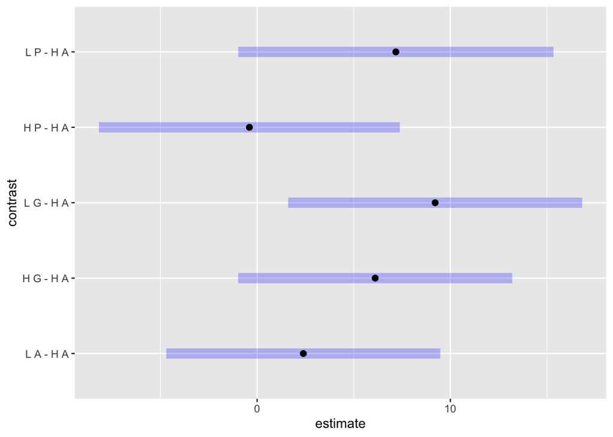

```r
# first here's all of the contrasts plotted:
plot(nut_food_emmeans$contrasts)
```

```r
# take a look at order of levels in nut_food_emmeans
nut_food_emmeans
```

```
## $emmeans
##  NutrientLevel FoodWeb emmean   SE df lower.CL upper.CL
##  H             A        10.05 2.01 30     5.94     14.2
##  L             A        12.44 1.73 30     8.91     16.0
##  H             G        16.16 1.73 30    12.63     19.7
##  L             G        19.26 2.05 30    15.07     23.5
##  H             P         9.65 2.06 30     5.44     13.9
##  L             P        17.23 2.26 30    12.61     21.8
##
## Results are averaged over the levels of: Block
## Confidence level used: 0.95
##
## $contrasts
##  contrast  estimate   SE df t.ratio p.value
##  L A - H A    2.391 2.65 30   0.902  0.7930
##  H G - H A    6.110 2.65 30   2.304  0.1106
##  L G - H A    9.214 2.85 30   3.237  0.0130
##  H P - H A   -0.399 2.91 30  -0.137  0.9985
##  L P - H A    7.180 3.05 30   2.353  0.1000
##
## Results are averaged over the levels of: Block
## P value adjustment: dunnettx method for 5 tests
```

```r
custom_contrasts <- contrast(nut_food_emmeans, method = list(
         "H_G_vs_H_P" = c(0, 0, 1, 0, -1, 0),
         "L_G_vs_L_P" = c(0, 0, 0, 1, 0, -1)
         )
         )
custom_contrasts
```

```
##  contrast   estimate   SE df t.ratio p.value
##  H_G_vs_H_P     6.51 2.69 30   2.421  0.0217
##  L_G_vs_L_P     2.03 3.11 30   0.654  0.5182
##
## Results are averaged over the levels of: Block
```

```r
# provides the same p-values as the non-adjusted contrast:
nut_food_emmeans_no_adjust = emmeans(rich_model, specs = trt.vs.ctrl ~ NutrientLevel*FoodWeb, adjust = "none")
nut_food_emmeans_no_adjust
```

```
## $emmeans
##  NutrientLevel FoodWeb emmean   SE df lower.CL upper.CL
##  H             A        10.05 2.01 30     5.94     14.2
##  L             A        12.44 1.73 30     8.91     16.0
##  H             G        16.16 1.73 30    12.63     19.7
##  L             G        19.26 2.05 30    15.07     23.5
##  H             P         9.65 2.06 30     5.44     13.9
##  L             P        17.23 2.26 30    12.61     21.8
##
## Results are averaged over the levels of: Block
## Confidence level used: 0.95
##
## $contrasts
##  contrast  estimate   SE df t.ratio p.value
##  L A - H A    2.391 2.65 30   0.902  0.3745
##  H G - H A    6.110 2.65 30   2.304  0.0284
##  L G - H A    9.214 2.85 30   3.237  0.0029
##  H P - H A   -0.399 2.91 30  -0.137  0.8920
##  L P - H A    7.180 3.05 30   2.353  0.0254
##
## Results are averaged over the levels of: Block
```

- G has significantly higher richness than P in the H treatment, but not in the L treatment
3. whether G is different from P when averaging over the L and H treatments.

```r
# want a new emmeans without the interaction with nutrient level
nut_emmeans = emmeans(rich_model, specs = trt.vs.ctrl ~ FoodWeb)
```

```
## NOTE: Results may be misleading due to involvement in interactions
```

```r
nut_emmeans
```

```
## $emmeans
##  FoodWeb emmean   SE df lower.CL upper.CL
##  A         11.2 1.33 30     8.53     14.0
##  G         17.7 1.34 30    14.97     20.4
##  P         13.4 1.57 30    10.23     16.6
##
## Results are averaged over the levels of: NutrientLevel, Block
## Confidence level used: 0.95
##
## $contrasts
##  contrast estimate   SE df t.ratio p.value
##  G - A        6.47 1.88 30   3.448  0.0033
##  P - A        2.19 2.08 30   1.056  0.4790
##
## Results are averaged over the levels of: NutrientLevel, Block
## P value adjustment: dunnettx method for 2 tests
```

```r
# results may be misleading? hmm...

# I'm not sure if we also need to make a new model, warning suggests so...
simple_model <- lm(Phyto_Chao1 ~ FoodWeb + NutrientLevel + Block,
            data = data)
summary(simple_model)
```

```
##
## Call:
## lm(formula = Phyto_Chao1 ~ FoodWeb + NutrientLevel + Block, data = data)
##
## Residuals:
##     Min      1Q  Median      3Q     Max
## -8.6301 -3.6988  0.1508  2.8395 10.1867
##
## Coefficients:
##                Estimate Std. Error t value Pr(>|t|)
## (Intercept)      9.8133     2.0158   4.868 2.91e-05 ***
## FoodWebG         6.6867     1.8657   3.584  0.00111 **
## FoodWebP         2.1574     2.0636   1.045  0.30365
## NutrientLevelL   4.1301     1.5779   2.617  0.01342 *
## Block2          -0.1215     2.1657  -0.056  0.95562
## Block3          -1.2253     2.0920  -0.586  0.56219
## Block4          -1.7217     2.3103  -0.745  0.46158
## ---
## Signif. codes:  0 '***' 0.001 '**' 0.01 '*' 0.05 '.' 0.1 ' ' 1
##
## Residual standard error: 4.879 on 32 degrees of freedom
## Multiple R-squared:  0.3664, Adjusted R-squared:  0.2477
## F-statistic: 3.085 on 6 and 32 DF,  p-value: 0.01693
```

```r
nut_emmeans = emmeans(simple_model, specs = trt.vs.ctrl ~ FoodWeb)
nut_emmeans
```

```
## $emmeans
##  FoodWeb emmean   SE df lower.CL upper.CL
##  A         11.1 1.31 32     8.44     13.8
##  G         17.8 1.33 32    15.10     20.5
##  P         13.3 1.56 32    10.08     16.5
##
## Results are averaged over the levels of: NutrientLevel, Block
## Confidence level used: 0.95
##
## $contrasts
##  contrast estimate   SE df t.ratio p.value
##  G - A        6.69 1.87 32   3.584  0.0022
##  P - A        2.16 2.06 32   1.045  0.4849
##
## Results are averaged over the levels of: NutrientLevel, Block
## P value adjustment: dunnettx method for 2 tests
```

```r
# one custom contrast
custom_contrast <- contrast(nut_emmeans, method = list(
         "G_vs_P" = c(0, 1, -1)
         )
         )
custom_contrast
```

```
##  contrast estimate   SE df t.ratio p.value
##  G_vs_P       4.53 2.07 32   2.184  0.0364
##
## Results are averaged over the levels of: NutrientLevel, Block
```

- yes, G has a significantly higher species richness than P when averaging across nutrient level and block treatments

Finally, (4) define an interaction contrast that tests whether the difference between G and P is itself different between L and H treatments. I.e., is (G – P) for the high nutrient treatments greater or smaller than (G – P) for the low nutrient treatments?

```r
nut_food_emmeans
```

```
## $emmeans
##  NutrientLevel FoodWeb emmean   SE df lower.CL upper.CL
##  H             A        10.05 2.01 30     5.94     14.2
##  L             A        12.44 1.73 30     8.91     16.0
##  H             G        16.16 1.73 30    12.63     19.7
##  L             G        19.26 2.05 30    15.07     23.5
##  H             P         9.65 2.06 30     5.44     13.9
##  L             P        17.23 2.26 30    12.61     21.8
##
## Results are averaged over the levels of: Block
## Confidence level used: 0.95
##
## $contrasts
##  contrast  estimate   SE df t.ratio p.value
##  L A - H A    2.391 2.65 30   0.902  0.7930
##  H G - H A    6.110 2.65 30   2.304  0.1106
##  L G - H A    9.214 2.85 30   3.237  0.0130
##  H P - H A   -0.399 2.91 30  -0.137  0.9985
##  L P - H A    7.180 3.05 30   2.353  0.1000
##
## Results are averaged over the levels of: Block
## P value adjustment: dunnettx method for 5 tests
```

```r
interaction_contrast <- contrast(nut_food_emmeans,
         list("HG_min_HP" = c(0, 0, 1, 0, -1, 0),
              "LG_min_LP" = c(0, 0, 0, 1, 0, -1)
              ))
interaction_contrast
```

```
##  contrast  estimate   SE df t.ratio p.value
##  HG_min_HP     6.51 2.69 30   2.421  0.0217
##  LG_min_LP     2.03 3.11 30   0.654  0.5182
##
## Results are averaged over the levels of: Block
```

#10. How do you interpret the results?

- The difference between G and P is only significant in the high nutrient treatment, where G has 6.51 more species than P. In the low treatment the difference between G and P is insignificant.